# MUSHROOM Dataset - Information Gain

Rajiv

24 July 2017

# Calculating Purity Measures: Accuracy, Entropy, GiniIndex

In this exercise we are going to calculate the information gain of the Mushroom Dataset using the 3 measures Accuracy, Entropy and Gini Index.

The Mushroom dataset has 4869 observations and 23 variables. This is obtained from the UCI Machine learning Repository and for more detailed information on this dataset refer to https://archive.ics.uci.edu/ml/machine-learning-databases/mushroom/agaricus-lepiota.names

Information gain is used to choose the best feature in predicting our response categorical which will be used for classification in building up the decision trees.

## ————————————————————————————————————-

**Loading the Mushroom dataset from Git Repository**

```r
rm(list=ls())
Mushroom_train <- read.csv("https://raw.githubusercontent.com/Rajiv2806/Mushroom-Dataset/master/Mushroom%20train.csv",header = T)
Mushroom_train <- Mushroom_train[,2:24]
```

Looking at the structure of the dataset.

```r
head(Mushroom_train,5)
```

```
##   V1 V2 V3 V4 V5 V6 V7 V8 V9 V10 V11 V12 V13 V14 V15 V16 V17 V18 V19 V20
## 1  p  x  s  n  t  p  f  c  n   k   e   e   s   s   w   w   p   w   o   p
## 2  e  x  s  y  t  a  f  c  b   k   e   c   s   s   w   w   p   w   o   p
## 3  p  x  y  w  t  p  f  c  n   n   e   e   s   s   w   w   p   w   o   p
## 4  e  x  y  y  t  a  f  c  b   n   e   c   s   s   w   w   p   w   o   p
## 5  e  b  y  w  t  l  f  c  b   n   e   c   s   s   w   w   p   w   o   p
##   V21 V22 V23
## 1   k   s   u
## 2   n   n   g
## 3   k   s   u
## 4   k   n   g
## 5   n   s   m
```

# Accuracy

Below is the code to calculate the Accuracy of an feature based on the the dependant variable Y which is V1 in this case.

```r
t1 = Sys.time()

A1 <- c()
for(i in 2:23){
    A2 <- as.data.frame(table(Mushroom_train[,1],Mushroom_train[,i]))
    names(A2) <- c("var1","var2","Freq")
    A3 <- unique(A2$var2)
    A4 <- c()
    A6 <- c()
    for(j in 1:length(A3)){A4[j] <- max(A2[A2$var2 %in% A3[j],]$Freq)/sum(A2[A2$var2 %in% A3[j],]$Freq)}
    for(k in 1:length(A3)){A6[k] <- (sum(A2[A2$var2 %in% A3[k],]$Freq)/nrow(Mushroom_train)) * A4[k]}
    A1[i] <- sum(A6)}

# As i values starts from 2 in A1 as per the above for loop, we remove the first value from A1
A1 <- na.omit(A1)

# Creating a Data frame of the variables and the accuracy scores
A5 <- as.data.frame(cbind(names(Mushroom_train[,-c(1)]),A1))
A5$A1 <- as.numeric(as.character(A5$A1))
A5$A1 <- (A5$A1)*100

#Renaming the same table above A5 to AccuracyTable ordered by the Descending values of their accuracy scores.
# and renaming the columns
AccuracyTable <- A5[order(-A5$A1),]
names(AccuracyTable) <- c("Variable","AccuracyScore")

head(AccuracyTable)
```

```
##    Variable AccuracyScore
## 5        V6      98.45964
## 20      V21      86.91723
## 9       V10      81.55679
## 19      V20      78.08585
## 12      V13      77.01787
## 13      V14      76.60711
```

```r
tail(AccuracyTable)
```

```
##    Variable AccuracyScore
## 1        V2      56.25385
## 10      V11      54.63134
## 18      V19      53.87143
## 17      V18      52.00246
## 6        V7      51.87924
## 16      V17      51.87924
```

```r
Sys.time() - t1
```

```
## Time difference of 0.140008 secs
```

```r
rm(A1,A2,A3,A4,A5,A6,t1,i,j,k)
```

# Gini Index

```r
t1 = Sys.time()

G1 <- c()

for(i in 2:23){
    G2 <- as.data.frame(table(Mushroom_train[,1],Mushroom_train[,i]))
    names(G2) <- c("var1","var2","Freq")
    G3 <- unique(G2$var2)
    G7 <- unique(G2$var1)
    G8 <- c()
    G6 <- c()
    for(j in 1:length(G3)){
        G4 <- c()
        for(p in 1:length(G7)){
            G4[p] <- (G2[G2$var2 %in% G3[j],]$Freq[p]/sum(G2[G2$var2 %in% G3[j],]$Freq))^2
        }
            G8[j] <- sum(G4)
    }
    for(k in 1:length(G3)){
        G6[k] <- (sum(G2[G2$var2 %in% G3[k],]$Freq)/nrow(Mushroom_train)) * G8[k]
    }
    G1[i] <- sum(G6)
}

G1 <- na.omit(G1)
G5 <- as.data.frame(cbind(names(Mushroom_train[,-c(1)]),G1))
G5$G1 <- as.numeric(as.character(G5$G1))
G5$G1 <- (G5$G1) * 100

GiniIndexTable <- G5[order(-G5$G1),]
names(GiniIndexTable) <- c("Variable","GiniScore")

head(GiniIndexTable)
```

```
##    Variable GiniScore
## 5        V6  97.02858
## 20      V21  78.59098
## 9       V10  74.18543
## 19      V20  68.66851
## 12      V13  66.76859
## 13      V14  66.57463
```

```r
tail(GiniIndexTable)
```

```
##    Variable GiniScore
## 18      V19  52.39884
## 2        V3  51.96239
## 17      V18  51.31418
## 6        V7  50.97708
## 10      V11  50.46122
## 16      V17  50.07063
```

```r
Sys.time() - t1
```

```
## Time difference of 0.1860111 secs
```

```r
rm(G1,G2,G3,G4,G5,G6,G7,G8,i,j,k,t1,p)
```

# Entropy

```r
t1 = Sys.time()

E5 <- c()

for(i in 2:23){
    E1 <- as.data.frame(table(Mushroom_train[,1],Mushroom_train[,i]))
    names(E1) <- c("Var1","Var2","Freq")
    E2 <- unique(E1$Var2)
    E3 <- c()
    for(j in 1:length(E2)){
        E3 <- E1[E1$Var2 %in% E2[j],]$Freq / sum(E1[E1$Var2 %in% E2[j],]$Freq)
        E3 <- -1 * E3 * log(E3,ifelse(length(E2) == 1,0,length(E2)))
        E3[is.nan(E3)] <- 0
        E4 <- sum(E3)
     }
    E5 <- c(E5,E4)
}

E6 <- names(Mushroom_train[,2:23])

EntropyTable <- as.data.frame(cbind(E6,E5))
names(EntropyTable) <- c("Variable","EntropyScore")
EntropyTable$EntropyScore <- as.numeric(as.character(EntropyTable$EntropyScore))*100
EntropyTable <- EntropyTable[order(-EntropyTable$EntropyScore),]

head(EntropyTable,5)
```

```
##    Variable EntropyScore
## 6        V7     99.98334
## 10      V11     99.04701
## 4        V5     68.60748
## 8        V9     50.89939
## 2        V3     49.84516
```

```r
tail(EntropyTable,5)
```

```
##    Variable EntropyScore
## 15      V16            0
## 16      V17            0
## 17      V18            0
## 20      V21            0
## 22      V23            0
```

```r
Sys.time() - t1
```

```
## Time difference of 0.111007 secs
```

```r
rm(E1,E2,E3,E4,E5,E6,t1,i,j)
```

# Creatring a Combined DataFrame With all Metrics

```r
FinalDF <- merge(x = AccuracyTable,y = EntropyTable,by.x = c("Variable"),by.y = c("Variable"))
FinalDF <- merge(x = FinalDF,y = GiniIndexTable,by.x = c("Variable"),by.y = c("Variable"))

library(dplyr)
FinalDF <- arrange(FinalDF,desc(AccuracyScore))

head(FinalDF,5)
```

```
##   Variable AccuracyScore EntropyScore GiniScore
## 1       V6      98.45964      0.00000  97.02858
## 2      V21      86.91723      0.00000  78.59098
## 3      V10      81.55679     20.13767  74.18543
## 4      V20      78.08585     31.14218  68.66851
## 5      V13      77.01787     47.72170  66.76859
```

# Plot of Accuracy Vs 1-Entropy

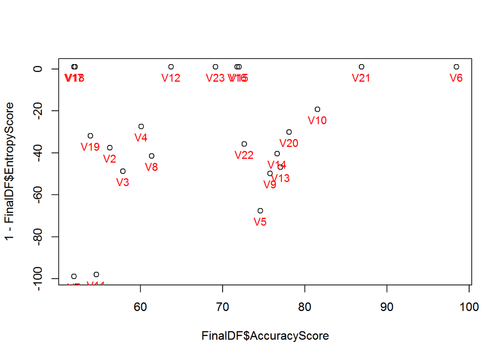

```r
plot(FinalDF$AccuracyScore,1-FinalDF$EntropyScore)
text(FinalDF$AccuracyScore,1-FinalDF$EntropyScore,FinalDF$Variable,cex=0.9,pos=1,col="red")
```

** Lets see which feature has the Highest Accuracy score, Highest Gini Index and Lowest Entropy score.**

```r
paste0("Max Accuracy Score: ", FinalDF[FinalDF$AccuracyScore == max(FinalDF$AccuracyScore),]$Variable)
```

```
## [1] "Max Accuracy Score: V6"
```

```r
paste0('Min Entropy Score: ')
```

```
## [1] "Min Entropy Score: "
```

```r
paste0(FinalDF[FinalDF$EntropyScore == min(FinalDF$EntropyScore),]$Variable)
```

```
## [1] "V6"  "V21" "V15" "V16" "V23" "V12" "V18" "V17"
```

```r
paste0("Max Gini Index Score: ")
```

```
## [1] "Max Gini Index Score: "
```

```r
paste0(FinalDF[FinalDF$GiniScore == max(FinalDF$GiniScore),]$Variable)
```

```
## [1] "V6"
```